# Bounce Rate / TTFB Prediction

# Predicting TTFB Impact on Bounce Rate

Using Machine Learning to Relate Page Speed Performance to Business Metrics

Return to Overview

It’s often difficult to portray that impact page speed has on business metrics such as conversion rate and bounce rate. We wanted to make an algorithm that can tell us something along the lines of “If we improve Time to First Byte by x%, bounce rate will improve y%” in order to make a business case for page speed improvements.  
Data comes from an anonymous client and is unavailable for public view

# Exploratory Data Analysis

We start, as always, by looking at what our data contains.

```r
summary(performanceRaw)
```

```
##      time             pageName         visitorType           device
##  Length:4740        Length:4740        Length:4740        Length:4740
##  Class :character   Class :character   Class :character   Class :character
##  Mode  :character   Mode  :character   Mode  :character   Mode  :character
##   firstByte         largestContentfulPaint cumulativeLayoutShift
##  Length:4740        Length:4740            Length:4740
##  Class :character   Class :character       Class :character
##  Mode  :character   Mode  :character       Mode  :character
##  intToNextPaint
##  Length:4740
##  Class :character
##  Mode  :character
```

No missing values, but I don’t like how data that should be numerical is character type. I fix that, and do a little bit of feature engineering to make our model more powerful; I’ll create a column representing the day of the week, and a column representing the month. Since I want to look at bounce rate, I’ll calculate that out real quick as well.

```r
combDF <- performanceRaw %>%
  left_join(bounceRaw, by=c("time", "device", "visitorType", "pageName")) %>%
  mutate_at(vars(-time, -pageName, -device), ~as.numeric(.)) %>%
  mutate(time =  as.POSIXct(as.numeric(time), origin = "1970-01-01"),
         dow = wday(time, week_start = 1),
         dowString = wday(time, week_start = 1, label = TRUE),
         dowString = forcats::fct_rev(dowString),
         bounceRate = round(((visitors-nonBounceCount)/visitors)*100, 2),
         revPerVisitor = round(revenue/visitors, 2),
         visitorTypeString = ifelse(visitorType == 0, "New", "Returning"),
         deviceNumeric = ifelse(device == "Desktop", 0, 1)
         ) %>%
  filter(pageName == 'cdp') #We'll only look at one type of page to start with
summary(combDF)
```

```
##       time                       pageName          visitorType
##  Min.   :2024-08-01 00:00:00   Length:1580        Min.   :0.0
##  1st Qu.:2024-11-06 23:00:00   Class :character   1st Qu.:0.0
##  Median :2025-02-13 23:00:00   Mode  :character   Median :0.5
##  Mean   :2025-02-13 23:00:00                      Mean   :0.5
##  3rd Qu.:2025-05-24 00:00:00                      3rd Qu.:1.0
##  Max.   :2025-08-30 00:00:00                      Max.   :1.0
##
##     device            firstByte      largestContentfulPaint
##  Length:1580        Min.   : 222.0   Min.   : 916
##  Class :character   1st Qu.: 579.8   1st Qu.:2320
##  Mode  :character   Median : 946.0   Median :2927
##                     Mean   : 878.6   Mean   :3016
##                     3rd Qu.:1134.0   3rd Qu.:3483
##                     Max.   :1433.0   Max.   :7356
##
##  cumulativeLayoutShift intToNextPaint      visitors      nonBounceCount
##  Min.   :0.01548       Min.   :  89.0   Min.   :  8203   Min.   :  6670
##  1st Qu.:0.05480       1st Qu.: 176.0   1st Qu.: 24743   1st Qu.: 21260
##  Median :0.09127       Median : 220.5   Median : 42672   Median : 32063
##  Mean   :0.10725       Mean   : 339.7   Mean   : 48959   Mean   : 38847
##  3rd Qu.:0.14563       3rd Qu.: 397.0   3rd Qu.: 63911   3rd Qu.: 48189
##  Max.   :0.33340       Max.   :1667.0   Max.   :728502   Max.   :629070
##
##    exitCount         revenue         conversions         dow        dowString
##  Min.   :  6893   Min.   :  45630   Min.   :  363   Min.   :1.000   Sun:224
##  1st Qu.: 17620   1st Qu.: 162623   1st Qu.: 1055   1st Qu.:2.000   Sat:228
##  Median : 31658   Median : 225095   Median : 1482   Median :4.000   Fri:228
##  Mean   : 38388   Mean   : 312314   Mean   : 1980   Mean   :4.008   Thu:228
##  3rd Qu.: 51014   3rd Qu.: 363648   3rd Qu.: 2234   3rd Qu.:6.000   Wed:224
##  Max.   :589422   Max.   :5636376   Max.   :34772   Max.   :7.000   Tue:224
##                                                                     Mon:224
##    bounceRate    revPerVisitor    visitorTypeString  deviceNumeric
##  Min.   : 6.54   Min.   : 0.830   Length:1580        Min.   :0.0
##  1st Qu.:12.64   1st Qu.: 3.575   Class :character   1st Qu.:0.0
##  Median :17.91   Median : 6.830   Mode  :character   Median :0.5
##  Mean   :19.40   Mean   : 7.660                      Mean   :0.5
##  3rd Qu.:25.53   3rd Qu.:10.947                      3rd Qu.:1.0
##  Max.   :43.45   Max.   :52.480                      Max.   :1.0
##
```

Before we dive into creating the model, we need to get an idea of what is in the data and how it moves. We can’t go selecting features willy-nilly. Let’s start by looking at the relationship between bounce rate and Time to First Byte

[interactive chart not shown]

There’s two distinct peaks of visitors who experience a typical TTFB; I hypothesize based on my experience these two peaks relate to device type, desktop and mobile. It also seems bounce rate does go up as TTFB does, up to a point. This is typical behavior the industry hasn’t quite figured out the reason for; the majority seems to believe this small population of users understand they have slow-performing devices and therefore “just deal with it.” I also have a theory that there exists a small population of extremely driven shoppers who will convert no matter what page speed experience they are served.

Let’s look at some segments and see how their bounce rate deviates from the overall:

[interactive chart not shown]

And it seems that device type matters when it comes to bounce rate, but user type not so much. We’ll have to include device type in our model

I want to also look at day of week, and month to determine if we should include those in the model as well. Might as well look at how the distribution of bounce rate itself looks as well.

[interactive chart not shown]

Overall bounce rate looks about as wonky as one would expect. It is interesting to see the different distibutions of bounce rate for user type, considering their average bounce rate is similar. It doesn’t look like the day of the week is a particularly strong predictor of bounce rate, so we most likely won’t use that as a feature in the model.  
Last thing before getting into the model is to determine if the month has an impact on bounce rate. I can do this with a simple scatter plot

[interactive chart not shown]

It doesn’t seem to matter for a few months, but there are definitely little clusters of the same color. Will probably have to add in month as a feature as well.

# Building the Model

Let’s get to building the model. I clean the data up a little by removing anything above the 99th percentile, treating them as outliers; Real User data is naturally messy. I am using a Generalized Additive Model (GAM) rather than a linear model because I want the model to be able to handle non-linear relationships, if they exist. We also can’t use a logistic regression since our target is not binary.  
TTFB is in a Tensor Product smooth function so it can benefit from the 2-dimenstions of visitor type; I chose to do this because of the different distributions for each type. Month is treated as a factor rather than put into its own smoothing function since it did not impact model performance much, and can simplify the model. Since bounce rate can be defined as numbers specifically between 0 and 1, I define the model to be a Beta regression specifically.  
Since we are using a Beta distribution, I use the logit link function to map the bound data to be unbound linear-friendly data. Our data definitely isn’t normalized, so pobit isn’t an option, and our bounce rate isn’t rare enough for the cloglog link function.

```r
gamModel <- gam(bounceRateDecimal ~ te(firstByte, by = visitorType, k=10) +
                monthFactor + deviceNumeric,
                data = modelDF,
                family = betar(link="logit"),
                method = "REML"
)
summary(gamModel)
```

```
##
## Family: Beta regression(150.639)
## Link function: logit
##
## Formula:
## bounceRateDecimal ~ te(firstByte, by = visitorType, k = 10) +
##     monthFactor + deviceNumeric
##
## Parametric coefficients:
##                 Estimate Std. Error  z value Pr(>|z|)
## (Intercept)    -1.947292   0.009387 -207.454   <2e-16 ***
## monthFactor.L   0.239935   0.021380   11.223   <2e-16 ***
## monthFactor.Q  -0.439550   0.039177  -11.220   <2e-16 ***
## monthFactor.C  -0.497653   0.022330  -22.286   <2e-16 ***
## monthFactor^4   0.365542   0.023471   15.574   <2e-16 ***
## monthFactor^5  -0.224509   0.021261  -10.560   <2e-16 ***
## monthFactor^6  -0.242754   0.020502  -11.840   <2e-16 ***
## monthFactor^7   0.037318   0.020118    1.855   0.0636 .
## monthFactor^8   0.317232   0.019677   16.122   <2e-16 ***
## monthFactor^9  -0.221507   0.020670  -10.716   <2e-16 ***
## monthFactor^10 -0.038861   0.019643   -1.978   0.0479 *
## monthFactor^11  0.165575   0.018327    9.035   <2e-16 ***
## deviceNumeric1  0.863331   0.011772   73.338   <2e-16 ***
## ---
## Signif. codes:  0 '***' 0.001 '**' 0.01 '*' 0.05 '.' 0.1 ' ' 1
##
## Approximate significance of smooth terms:
##                              edf Ref.df Chi.sq p-value
## te(firstByte):visitorType0 3.042  3.828  349.8  <2e-16 ***
## te(firstByte):visitorType1 6.925  7.997  109.7  <2e-16 ***
## ---
## Signif. codes:  0 '***' 0.001 '**' 0.01 '*' 0.05 '.' 0.1 ' ' 1
##
## R-sq.(adj) =  0.847   Deviance explained =   85%
## -REML = -3120.1  Scale est. = 1         n = 1532
```

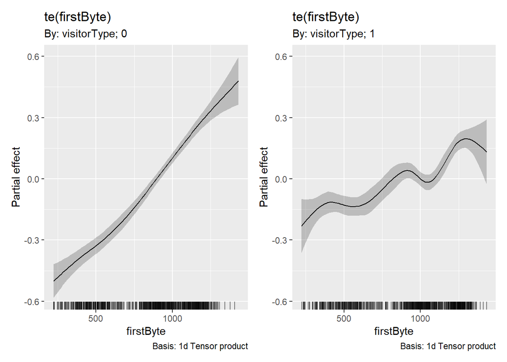

```
##
## Method: REML   Optimizer: outer newton
## full convergence after 5 iterations.
## Gradient range [-6.214738e-07,3.363821e-06]
## (score -3120.131 & scale 1).
## Hessian positive definite, eigenvalue range [0.2851741,755.1428].
## Model rank =  31 / 31
##
## Basis dimension (k) checking results. Low p-value (k-index<1) may
## indicate that k is too low, especially if edf is close to k'.
##
##                              k'  edf k-index p-value
## te(firstByte):visitorType0 9.00 3.04    1.01    0.68
## te(firstByte):visitorType1 9.00 6.93    1.01    0.68
```

Large p-values and k-index close to 1 shows that the model is using the appropriate ‘wiggly-ness.’ If the p-value was very small, it would indicate we need to increase the k-parameter in the model to allow for more splines.

# Evaluating the Model

Since our data is not Gaussian, a Q-Q plot would not be very helpful. Instead, we plot the fitted values against the real values directly to visualize how the model performs. Ideally, we want to see a linear relationship along the 45 degree line.

[interactive chart not shown]

The data is noisy, but a linear relationship can be seen between the real and fitted values, despite some outliers.

### MSE and RMSE

```r
trainIndex <- createDataPartition(modelDF$bounceRateDecimal, p = 0.7, list = FALSE) #70% of the data goes into the training set
trainDF <- modelDF[trainIndex, ]
testDF  <- modelDF[-trainIndex, ]

gamTrain <- gam(bounceRateDecimal ~ te(firstByte, by = visitorType, k=10) +
                  monthFactor + visitorType + deviceNumeric,
                data = trainDF,
                family = betar(link="logit"),
                method = "REML"
)
# Compute RMSE or MAE
pred <- predict(gamTrain, newdata=testDF, type="response")
rmse <- sqrt(mean((testDF$bounceRateDecimal - pred)^2))
mae  <- mean(abs(testDF$bounceRateDecimal - pred))
rmse; mae
```

```
## [1] 0.03046116
```

```
## [1] 0.02222605
```

```r
#Check for overfitting
months <- sort(unique(modelDF$monthFactor))
results <- data.frame()
for (m in months) {
  train <- filter(trainDF, monthFactor == m)
  test  <- filter(trainDF, monthFactor == m)
  fit <- gam(bounceRateDecimal ~ te(firstByte, by = visitorType, k=10) +
               visitorType + deviceNumeric,
             data = train, family = betar(link="logit"), method = "REML")
  pred <- predict(fit, newdata = test, type = "response")
  results <- rbind(results, data.frame(month = m,
                                       rmse = sqrt(mean((test$bounceRateDecimal - pred)^2)),
                                       mae = mean(abs(test$bounceRateDecimal - pred))))
}
results
```

```
##    month       rmse        mae
## 1     01 0.04152067 0.03103918
## 2     02 0.01338088 0.01080262
## 3     03 0.02659272 0.01571016
## 4     04 0.01677813 0.01424812
## 5     05 0.02896057 0.02341919
## 6     06 0.02311670 0.01536225
## 7     07 0.02302895 0.01483723
## 8     08 0.01498584 0.01176619
## 9     09 0.02627091 0.02124115
## 10    10 0.01999643 0.01662375
## 11    11 0.03192231 0.02520747
## 12    12 0.01643395 0.01296373
```

```r
mean(results$rmse); mean(results$mae)
```

```
## [1] 0.02358234
```

```
## [1] 0.01776842
```

### Concurvity

Concurvity is the GAM equivalent of multicollinearity. If one smooth or some combination of predictors can be closely predicted by another, the model would not be able to uniquely separate their effects. Large concurvity can cause estimates to become unstable, biases to emerge, and hurt interpretability of the model.

```r
concurvity(gamModel, full = TRUE)
```

```
##               para te(firstByte):visitorType0 te(firstByte):visitorType1
## worst    0.5950599                  0.6896842                  0.6951869
## observed 0.5950599                  0.6640588                  0.6071005
## estimate 0.5950599                  0.2010764                  0.2345440
```

# Defining the Relationship between TTFB and Bounce Rate

To derive a relationship between bounce rate and TTFB, new data is generated from the original data, changing the TTFB by x milliseconds. The new features are then ran through the GAM model, which predicts bounce rate at the new TTFB values. The data is then rejoined, and the difference between the bounce rates observed.

[interactive chart not shown]

And there it is! The plots show the estimated change in bounce rate for both user types and both device types. A point of diminishing return can be seen in all 4 groups. Returning users are the least impacted, but that makes sense since they’re typically the highest converting group.  
Next steps would most likely involve improving the model performance on the edge cases. My initial thought would be some sort of feature flag that indicates what percentile the data falls into; some experimentation would be needed.